# My R Markdown Primer

Christine Jacob

2025-11-12

## What is R Markdown?

R Markdown is a file format that allows you to combine narrative text, code, and formatted mathematical notation in a single, reproducible document. It supports embedded R code chunks whose results—such as printed output, tables, and plots—are included directly in the final HTML or PDF output. This makes it a powerful tool for data analysis, reporting, and reproducible research.

## Why R Markdown is Useful

One of the key strengths of R Markdown is its ability to keep analysis and explanation together. Rather than switching between separate documents for code and for reporting, R Markdown lets you work in a single file. This improves organization and helps ensure that results shown in the report always reflect the current version of the code.

## Mathematical Example

Inline math example: The linear model can be written as $\alpha + \beta = \gamma$.

Displayed equation:

$$y_i = \beta_0 + \beta_1 x_i + \epsilon_i$$
## Load library

```r
library(ggplot2)
data(mtcars)
head(mtcars)
```

```
##                    mpg cyl disp  hp drat    wt  qsec vs am gear carb
## Mazda RX4         21.0   6  160 110 3.90 2.620 16.46  0  1    4    4
## Mazda RX4 Wag     21.0   6  160 110 3.90 2.875 17.02  0  1    4    4
## Datsun 710        22.8   4  108  93 3.85 2.320 18.61  1  1    4    1
## Hornet 4 Drive    21.4   6  258 110 3.08 3.215 19.44  1  0    3    1
## Hornet Sportabout 18.7   8  360 175 3.15 3.440 17.02  0  0    3    2
## Valiant           18.1   6  225 105 2.76 3.460 20.22  1  0    3    1
```

## Generate a plot

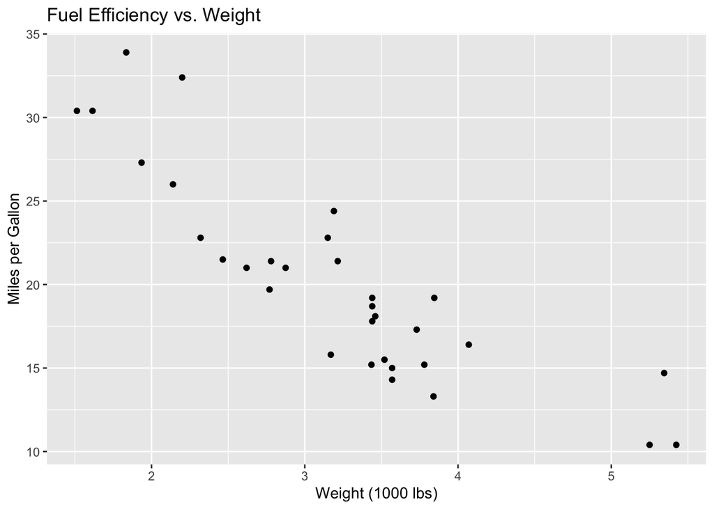

```r
ggplot(mtcars, aes(x = wt, y = mpg)) +
  geom_point() +
  labs(
    title = "Fuel Efficiency vs. Weight",
    x = "Weight (1000 lbs)",
    y = "Miles per Gallon"
  )
```

## Reflection

Using R Markdown provides a seamless way to combine computation and explanation. Compared to writing plain reports, R Markdown ensures that outputs are always up-to-date because they are generated directly from the code. This reduces errors and increases reproducibility, especially when sharing work with collaborators or revisiting analyses in the future.